# Communicate a data set

**project for Udacity Nanodegree by Léon de Jong**

Investigating the Prosper Loan dataset.

## Inital investigation of Dataset

As we are interested in the Yield of different listings, let's see how the listings in different yields compare. Also how do the ratings systems factor into this?

You will see the fairly regularly distributed amounts of listings in terms of the lenderyield. Pay close attention to the HR spike in the first plot.

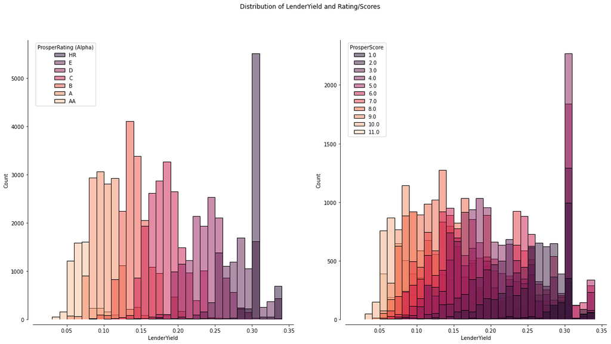

## Show relation between Scores, ratings and expected indicators

Let's look at some further indicator values besides the rating system. How do the amounts delinquent, creditscore range, debt to income ratio and the estimated losses stack up to the rating systems?

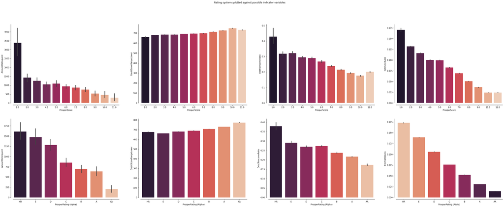

## Show skewdness in amounts delinquent.

The skewedness of the number of listings that have an amount delinquent and how much is shown in these plots. These suggest that a categorical indicator would be more usefull.

[output not shown]

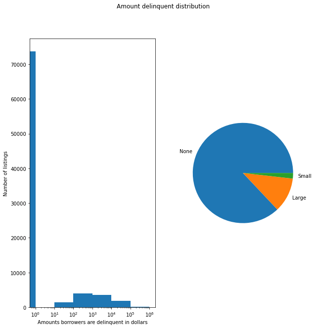

### Listing ratings and Delinquency

When transforming amounts delinquent into a categorical variable, what does this say about the listing ratings?

We see Lender Yields still improve per listing rating however we see yields increase with delinquencies. This effect is more pronounced in the Prosperscores as apposed to the prosper rating. The delinquencies play a larger role in the calculation of prosperscores apparently.

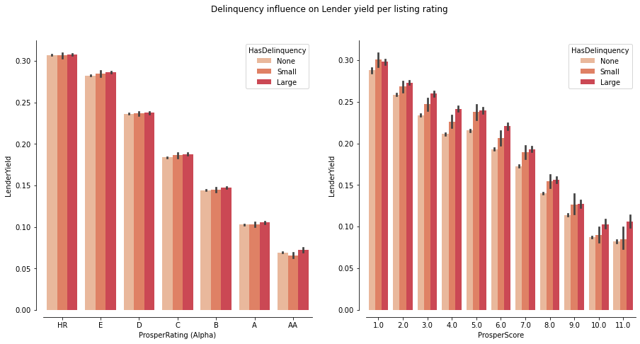

## Listing ratings and estimated losses

Here we can see a larger spread of estimated losses on the individual prosperscores than on the ratings. This suggests the Prosperscores are less influenced by the estimated losses.

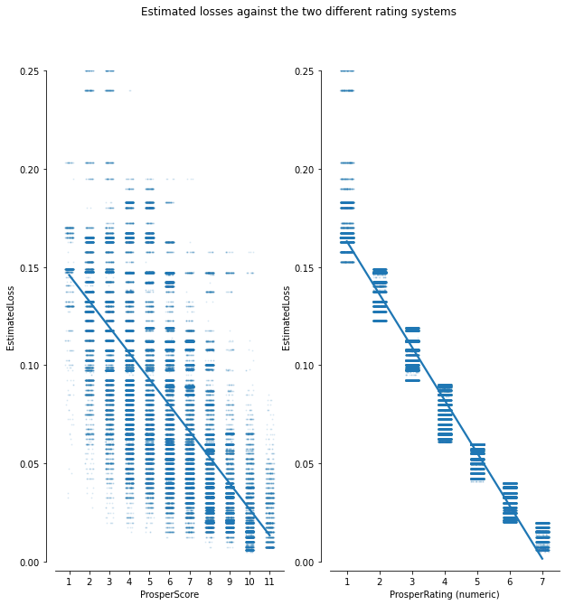

## Listing ratings and debt to income ratio

The debt to income ratio of borowwers may also play a role. However we can see the quartiles along the ratings mostly overlapping. It looks thus, like the Debt to Income ratio has little effect on the ratings.

```
(0.0, 2.0)
```

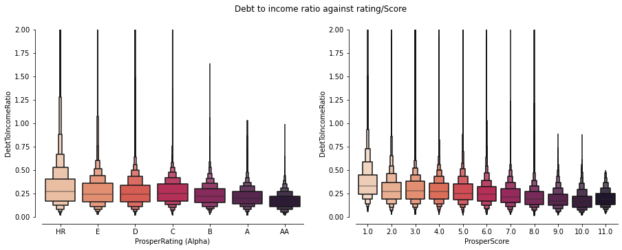

Plotting Lender yield to debt to income ratio's and limiting the debt to income ratio to 0.8, we can see that while debt to income ratio effects the Lender Yield to some extend, in terms of rating this effect is visible but very limited. Confirming the conclusions from above

```
(0.0, 0.8)
```

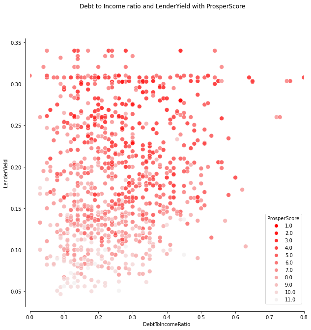

## Conclusion

### The Alpha rating is best to follow, but stay away from the rating "HR"

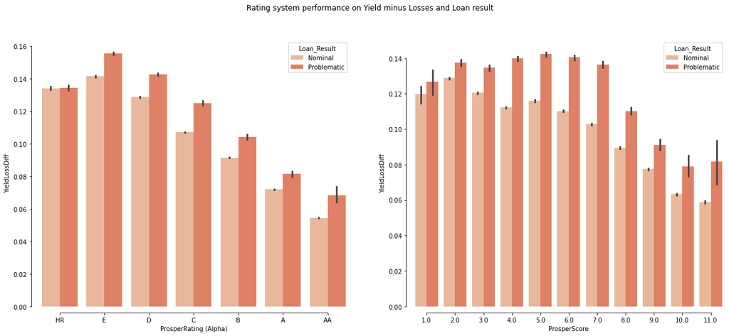